# 11_18_meeting_report

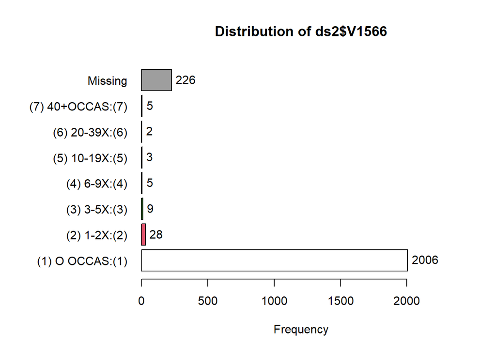

```
## ds2$V1566 :
##                  Frequency   %(NA+) cum.%(NA+)   %(NA-) cum.%(NA-)
## (1) O OCCAS:(1)       2006     87.8       87.8     97.5       97.5
## (2) 1-2X:(2)            28      1.2       89.1      1.4       98.8
## (3) 3-5X:(3)             9      0.4       89.4      0.4       99.3
## (4) 6-9X:(4)             5      0.2       89.7      0.2       99.5
## (5) 10-19X:(5)           3      0.1       89.8      0.1       99.7
## (6) 20-39X:(6)           2      0.1       89.9      0.1       99.8
## (7) 40+OCCAS:(7)         5      0.2       90.1      0.2      100.0
## NA's                   226      9.9      100.0      0.0      100.0
##   Total               2284    100.0      100.0    100.0      100.0
```

```r
tab1(ds2$V1566, cum.percent = TRUE)
```

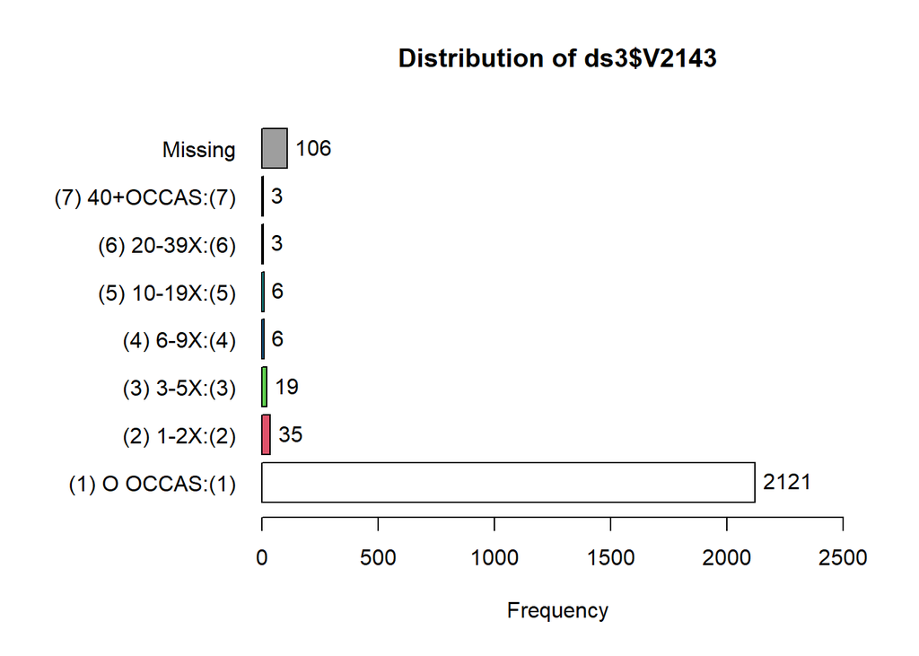

```
## ds3$V2143 :
##                  Frequency   %(NA+) cum.%(NA+)   %(NA-) cum.%(NA-)
## (1) O OCCAS:(1)       2121     92.3       92.3     96.7       96.7
## (2) 1-2X:(2)            35      1.5       93.8      1.6       98.3
## (3) 3-5X:(3)            19      0.8       94.6      0.9       99.2
## (4) 6-9X:(4)             6      0.3       94.9      0.3       99.5
## (5) 10-19X:(5)           6      0.3       95.1      0.3       99.7
## (6) 20-39X:(6)           3      0.1       95.3      0.1       99.9
## (7) 40+OCCAS:(7)         3      0.1       95.4      0.1      100.0
## NA's                   106      4.6      100.0      0.0      100.0
##   Total               2299    100.0      100.0    100.0      100.0
```

```r
tab1(ds3$V2143, cum.percent = TRUE)
```

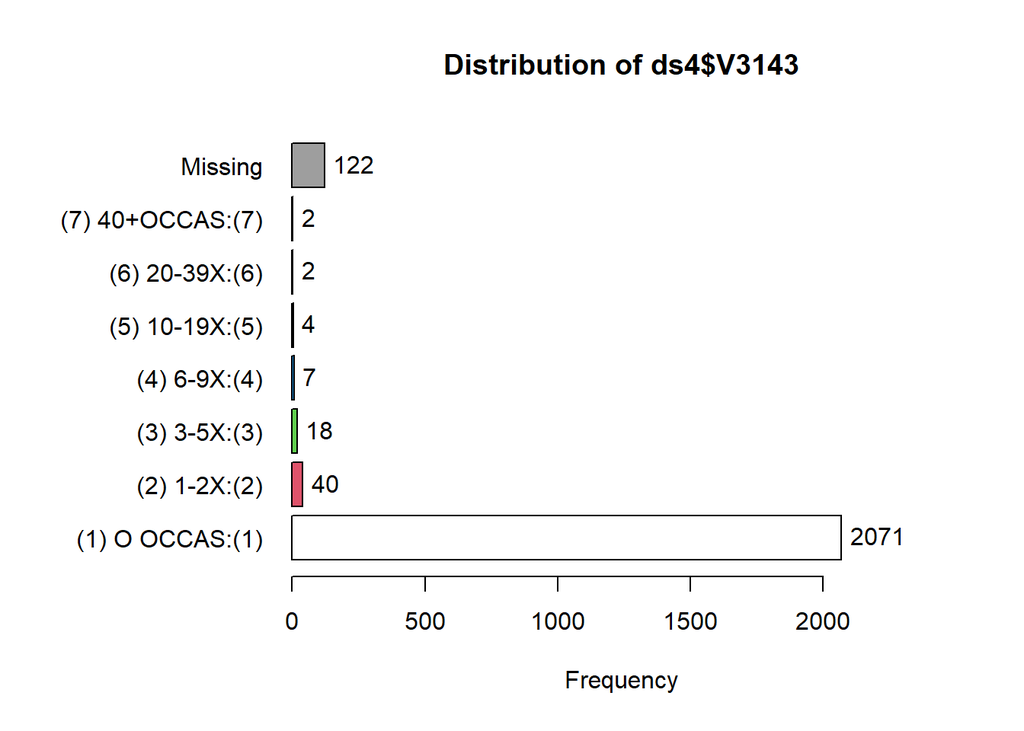

```
## ds4$V3143 :
##                  Frequency   %(NA+) cum.%(NA+)   %(NA-) cum.%(NA-)
## (1) O OCCAS:(1)       2071     91.4       91.4     96.6       96.6
## (2) 1-2X:(2)            40      1.8       93.2      1.9       98.5
## (3) 3-5X:(3)            18      0.8       94.0      0.8       99.3
## (4) 6-9X:(4)             7      0.3       94.3      0.3       99.6
## (5) 10-19X:(5)           4      0.2       94.4      0.2       99.8
## (6) 20-39X:(6)           2      0.1       94.5      0.1       99.9
## (7) 40+OCCAS:(7)         2      0.1       94.6      0.1      100.0
## NA's                   122      5.4      100.0      0.0      100.0
##   Total               2266    100.0      100.0    100.0      100.0
```

```r
tab1(ds4$V3143, cum.percent = TRUE)
```

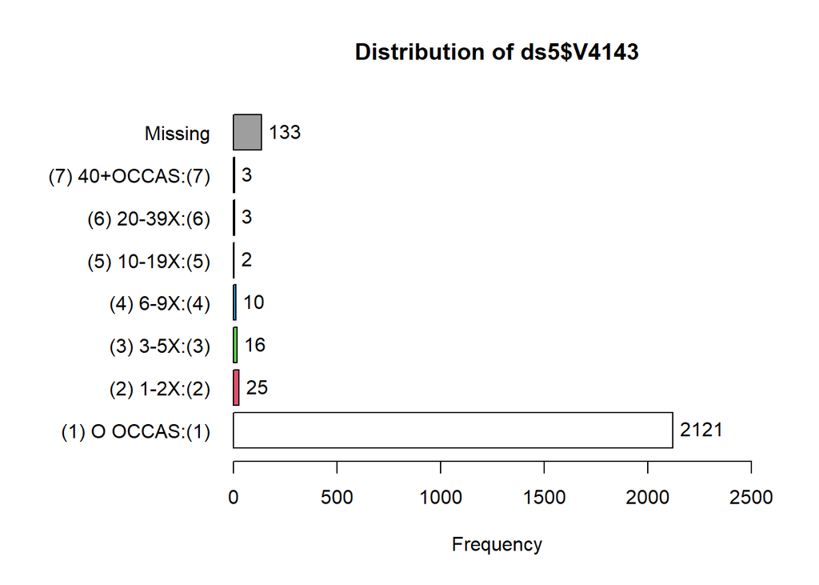

```
## ds5$V4143 :
##                  Frequency   %(NA+) cum.%(NA+)   %(NA-) cum.%(NA-)
## (1) O OCCAS:(1)       2121     91.7       91.7     97.3       97.3
## (2) 1-2X:(2)            25      1.1       92.8      1.1       98.4
## (3) 3-5X:(3)            16      0.7       93.5      0.7       99.2
## (4) 6-9X:(4)            10      0.4       93.9      0.5       99.6
## (5) 10-19X:(5)           2      0.1       94.0      0.1       99.7
## (6) 20-39X:(6)           3      0.1       94.1      0.1       99.9
## (7) 40+OCCAS:(7)         3      0.1       94.2      0.1      100.0
## NA's                   133      5.8      100.0      0.0      100.0
##   Total               2313    100.0      100.0    100.0      100.0
```

```r
tab1(ds5$V4143, cum.percent = TRUE)
```

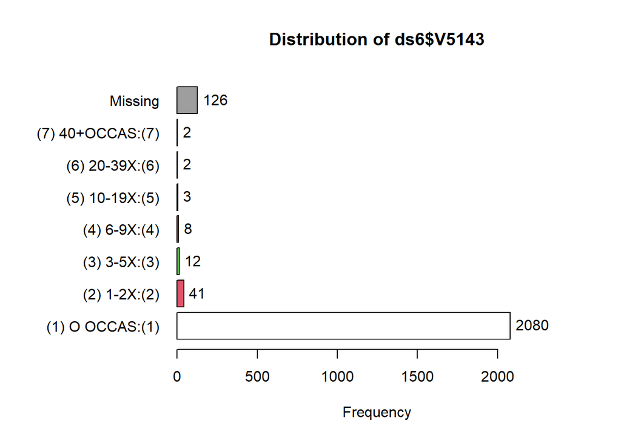

```
## ds6$V5143 :
##                  Frequency   %(NA+) cum.%(NA+)   %(NA-) cum.%(NA-)
## (1) O OCCAS:(1)       2080     91.5       91.5     96.8       96.8
## (2) 1-2X:(2)            41      1.8       93.3      1.9       98.7
## (3) 3-5X:(3)            12      0.5       93.8      0.6       99.3
## (4) 6-9X:(4)             8      0.4       94.2      0.4       99.7
## (5) 10-19X:(5)           3      0.1       94.3      0.1       99.8
## (6) 20-39X:(6)           2      0.1       94.4      0.1       99.9
## (7) 40+OCCAS:(7)         2      0.1       94.5      0.1      100.0
## NA's                   126      5.5      100.0      0.0      100.0
##   Total               2274    100.0      100.0    100.0      100.0
```

```r
tab1(ds6$V5143, cum.percent = TRUE)
```

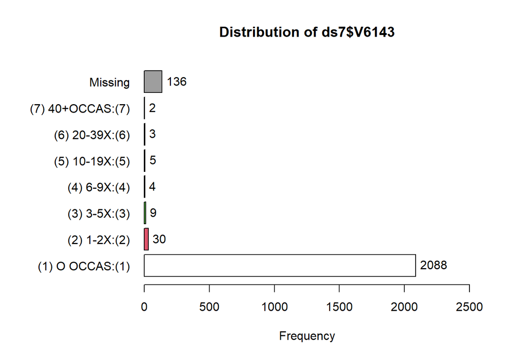

```
## ds7$V6143 :
##                  Frequency   %(NA+) cum.%(NA+)   %(NA-) cum.%(NA-)
## (1) O OCCAS:(1)       2088     91.7       91.7     97.5       97.5
## (2) 1-2X:(2)            30      1.3       93.0      1.4       98.9
## (3) 3-5X:(3)             9      0.4       93.4      0.4       99.3
## (4) 6-9X:(4)             4      0.2       93.6      0.2       99.5
## (5) 10-19X:(5)           5      0.2       93.8      0.2       99.8
## (6) 20-39X:(6)           3      0.1       93.9      0.1       99.9
## (7) 40+OCCAS:(7)         2      0.1       94.0      0.1      100.0
## NA's                   136      6.0      100.0      0.0      100.0
##   Total               2277    100.0      100.0    100.0      100.0
```

```r
tab1(ds7$V6143, cum.percent = TRUE)
```

### 00170:#X INHL/LAST12MO

On how many occasions (if any) have you sniffed glue, or breathed the contents of aerosol spray cans, or inhaled any other gases or sprays in order to get high . . . during the last 12 months?

1=“0 Occasions” 2=“1-2 Occasions” 3=“3-5 Occasions” 4=“6-9 Occasions” 5=“10-19 Occasions” 6=“20-39 Occasions” 7=“40 or More”

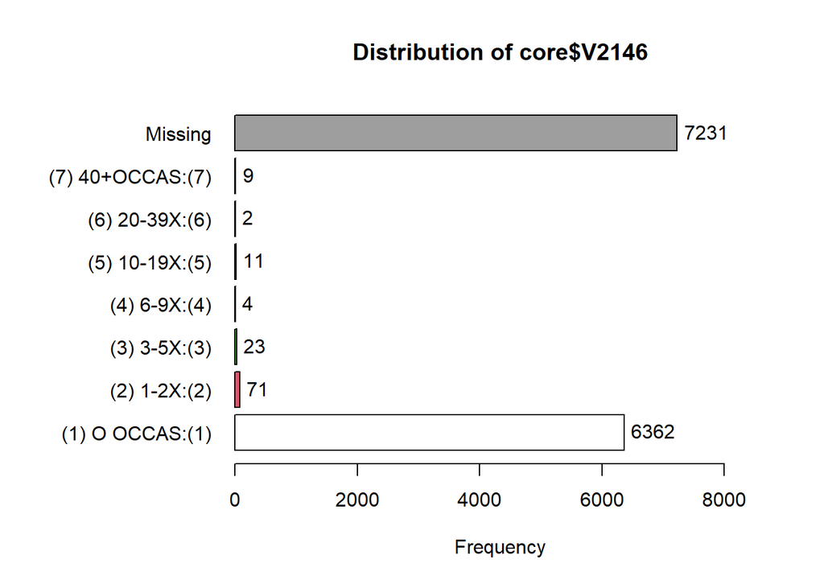

```
## core$V2146 :
##                  Frequency   %(NA+) cum.%(NA+)   %(NA-) cum.%(NA-)
## (1) O OCCAS:(1)       6362     46.4       46.4     98.1       98.1
## (2) 1-2X:(2)            71      0.5       46.9      1.1       99.2
## (3) 3-5X:(3)            23      0.2       47.1      0.4       99.6
## (4) 6-9X:(4)             4      0.0       47.1      0.1       99.7
## (5) 10-19X:(5)          11      0.1       47.2      0.2       99.8
## (6) 20-39X:(6)           2      0.0       47.2      0.0       99.9
## (7) 40+OCCAS:(7)         9      0.1       47.3      0.1      100.0
## NA's                  7231     52.7      100.0      0.0      100.0
##   Total              13713    100.0      100.0    100.0      100.0
```

```r
tab1(core$V2146, cum.percent = TRUE)
```

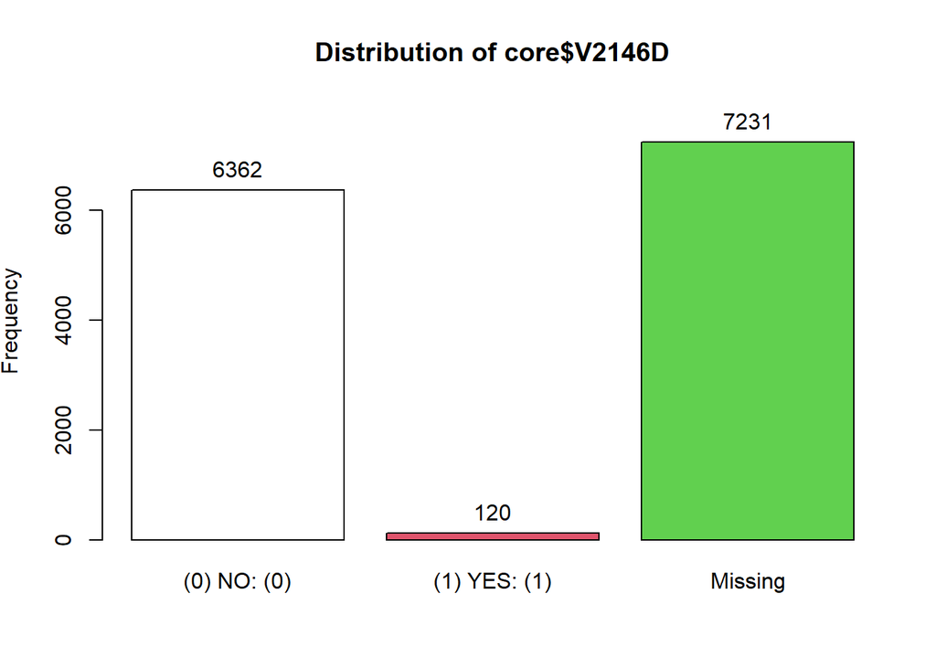

```
## core$V2146D :
##              Frequency   %(NA+) cum.%(NA+)   %(NA-) cum.%(NA-)
## (0) NO: (0)       6362     46.4       46.4     98.1       98.1
## (1) YES: (1)       120      0.9       47.3      1.9      100.0
## NA's              7231     52.7      100.0      0.0      100.0
##   Total          13713    100.0      100.0    100.0      100.0
```

```r
tab1(core$V2146D, cum.percent = TRUE)
```

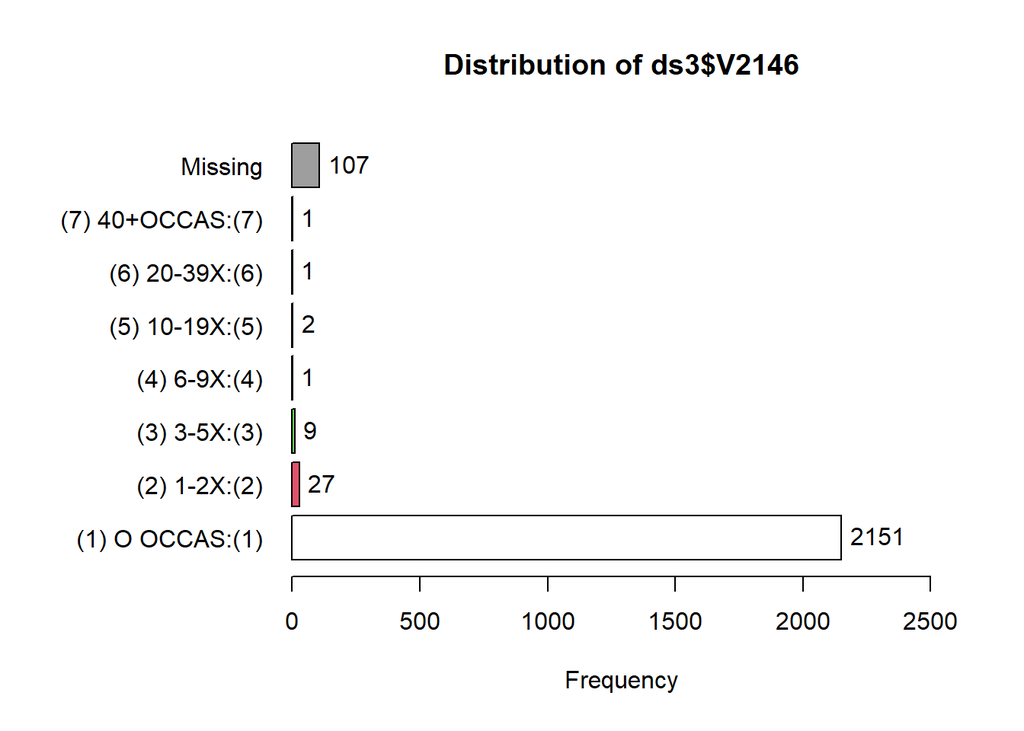

```
## ds3$V2146 :
##                  Frequency   %(NA+) cum.%(NA+)   %(NA-) cum.%(NA-)
## (1) O OCCAS:(1)       2151     93.6       93.6     98.1       98.1
## (2) 1-2X:(2)            27      1.2       94.7      1.2       99.4
## (3) 3-5X:(3)             9      0.4       95.1      0.4       99.8
## (4) 6-9X:(4)             1      0.0       95.2      0.0       99.8
## (5) 10-19X:(5)           2      0.1       95.3      0.1       99.9
## (6) 20-39X:(6)           1      0.0       95.3      0.0      100.0
## (7) 40+OCCAS:(7)         1      0.0       95.3      0.0      100.0
## NA's                   107      4.7      100.0      0.0      100.0
##   Total               2299    100.0      100.0    100.0      100.0
```

```r
tab1(ds3$V2146, cum.percent = TRUE)
```

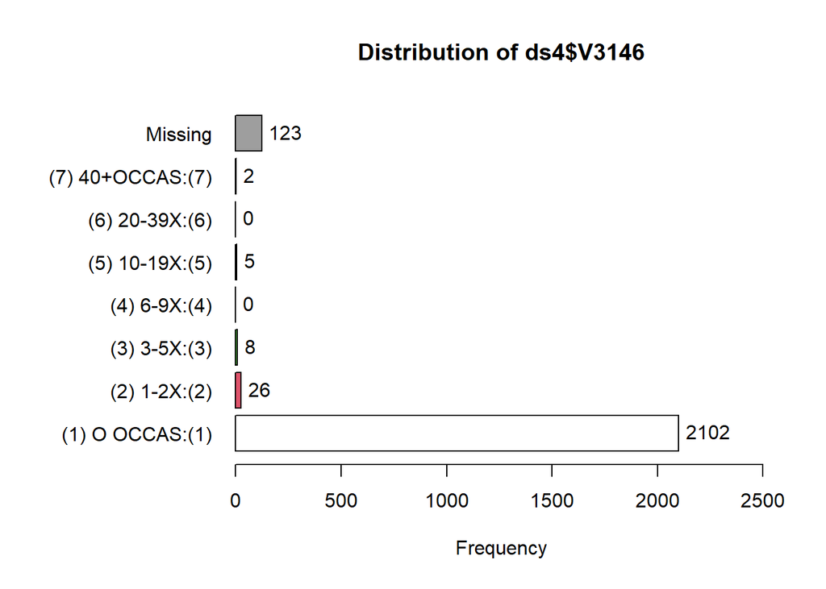

```
## ds4$V3146 :
##                  Frequency   %(NA+) cum.%(NA+)   %(NA-) cum.%(NA-)
## (1) O OCCAS:(1)       2102     92.8       92.8     98.1       98.1
## (2) 1-2X:(2)            26      1.1       93.9      1.2       99.3
## (3) 3-5X:(3)             8      0.4       94.3      0.4       99.7
## (4) 6-9X:(4)             0      0.0       94.3      0.0       99.7
## (5) 10-19X:(5)           5      0.2       94.5      0.2       99.9
## (6) 20-39X:(6)           0      0.0       94.5      0.0       99.9
## (7) 40+OCCAS:(7)         2      0.1       94.6      0.1      100.0
## NA's                   123      5.4      100.0      0.0      100.0
##   Total               2266    100.0      100.0    100.0      100.0
```

```r
tab1(ds4$V3146, cum.percent = TRUE)
```

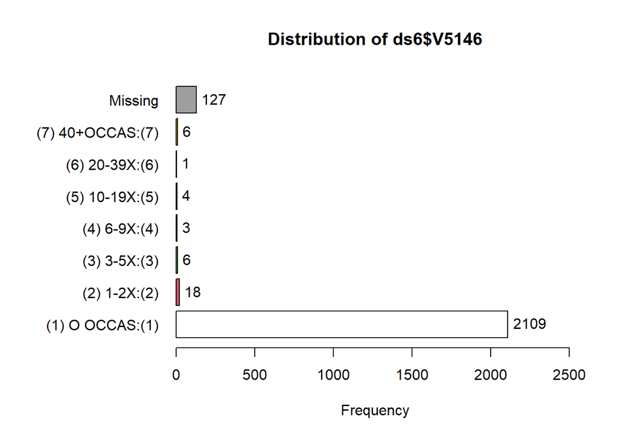

```
## ds6$V5146 :
##                  Frequency   %(NA+) cum.%(NA+)   %(NA-) cum.%(NA-)
## (1) O OCCAS:(1)       2109     92.7       92.7     98.2       98.2
## (2) 1-2X:(2)            18      0.8       93.5      0.8       99.1
## (3) 3-5X:(3)             6      0.3       93.8      0.3       99.3
## (4) 6-9X:(4)             3      0.1       93.9      0.1       99.5
## (5) 10-19X:(5)           4      0.2       94.1      0.2       99.7
## (6) 20-39X:(6)           1      0.0       94.2      0.0       99.7
## (7) 40+OCCAS:(7)         6      0.3       94.4      0.3      100.0
## NA's                   127      5.6      100.0      0.0      100.0
##   Total               2274    100.0      100.0    100.0      100.0
```

```r
tab1(ds6$V5146, cum.percent = TRUE)
```

### 22700:#X STRD/LAST12MO

{Anabolic steroids are prescription drugs sometimes prescribed by doctors to treat certain conditions. Some athletes, and others, have used them to try to increase muscle development.} On how many occasions (if any) have you taken steroids on your own–that is, without a doctor telling you to take them . . . during the last 12 months?

1=“0 Occasions” 2=“1-2 Occasions” 3=“3-5 Occasions” 4=“6-9 Occasions” 5=“10-19 Occasions” 6=“20-39 Occasions” 7=“40 or More”

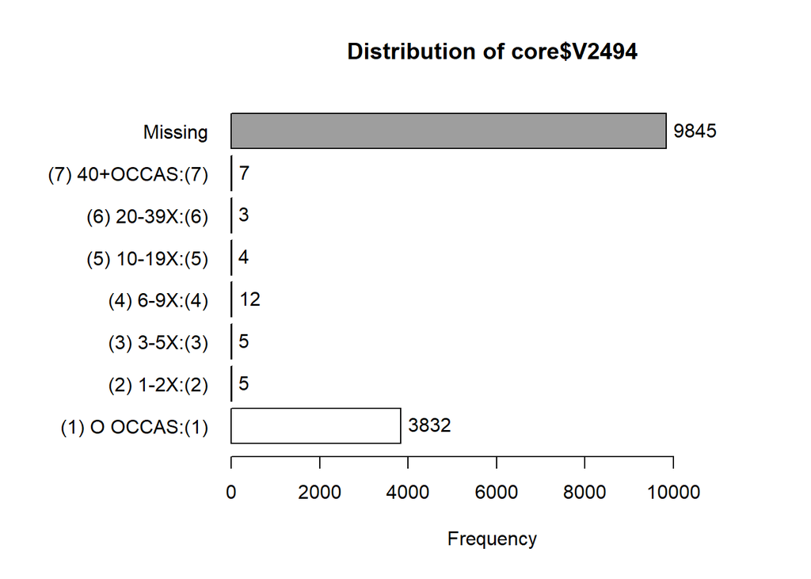

```
## core$V2494 :
##                  Frequency   %(NA+) cum.%(NA+)   %(NA-) cum.%(NA-)
## (1) O OCCAS:(1)       3832     27.9       27.9     99.1       99.1
## (2) 1-2X:(2)             5      0.0       28.0      0.1       99.2
## (3) 3-5X:(3)             5      0.0       28.0      0.1       99.3
## (4) 6-9X:(4)            12      0.1       28.1      0.3       99.6
## (5) 10-19X:(5)           4      0.0       28.1      0.1       99.7
## (6) 20-39X:(6)           3      0.0       28.2      0.1       99.8
## (7) 40+OCCAS:(7)         7      0.1       28.2      0.2      100.0
## NA's                  9845     71.8      100.0      0.0      100.0
##   Total              13713    100.0      100.0    100.0      100.0
```

```r
tab1(core$V2494, cum.percent = TRUE)
```

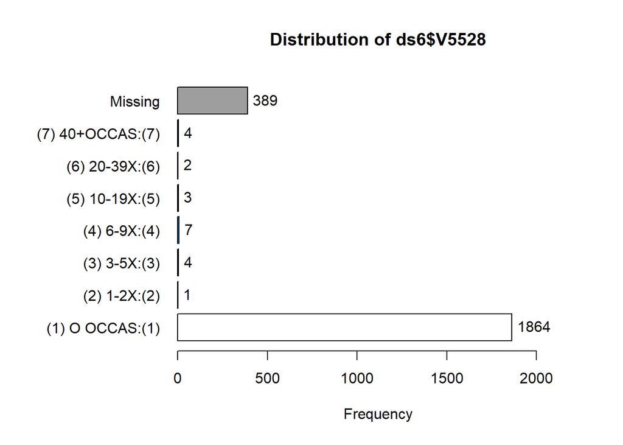

```
## ds6$V5528 :
##                  Frequency   %(NA+) cum.%(NA+)   %(NA-) cum.%(NA-)
## (1) O OCCAS:(1)       1864     82.0       82.0     98.9       98.9
## (2) 1-2X:(2)             1      0.0       82.0      0.1       98.9
## (3) 3-5X:(3)             4      0.2       82.2      0.2       99.2
## (4) 6-9X:(4)             7      0.3       82.5      0.4       99.5
## (5) 10-19X:(5)           3      0.1       82.6      0.2       99.7
## (6) 20-39X:(6)           2      0.1       82.7      0.1       99.8
## (7) 40+OCCAS:(7)         4      0.2       82.9      0.2      100.0
## NA's                   389     17.1      100.0      0.0      100.0
##   Total               2274    100.0      100.0    100.0      100.0
```

```r
tab1(ds6$V5528, cum.percent = TRUE)
```

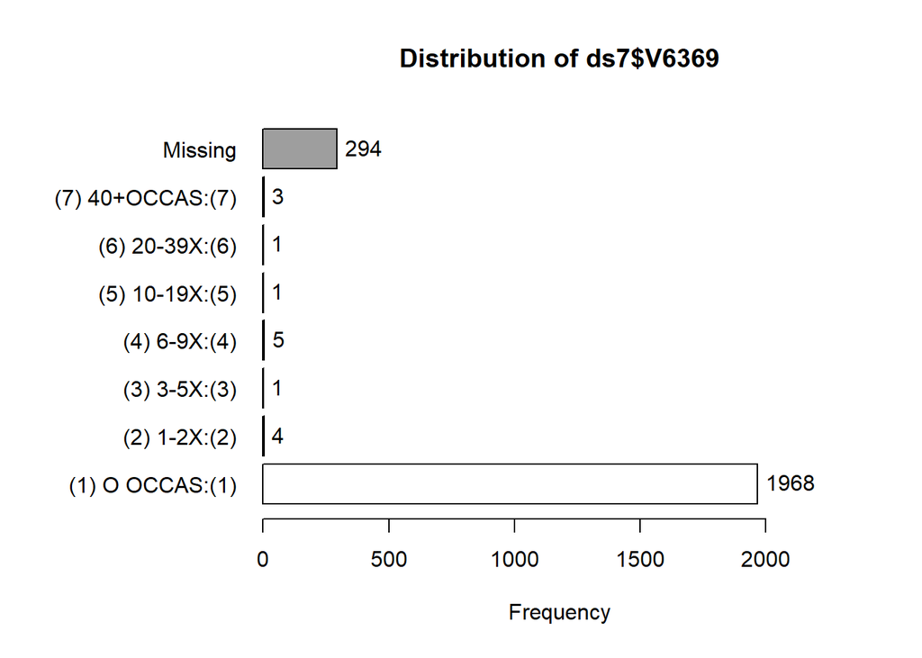

```
## ds7$V6369 :
##                  Frequency   %(NA+) cum.%(NA+)   %(NA-) cum.%(NA-)
## (1) O OCCAS:(1)       1968     86.4       86.4     99.2       99.2
## (2) 1-2X:(2)             4      0.2       86.6      0.2       99.4
## (3) 3-5X:(3)             1      0.0       86.6      0.1       99.5
## (4) 6-9X:(4)             5      0.2       86.9      0.3       99.7
## (5) 10-19X:(5)           1      0.0       86.9      0.1       99.8
## (6) 20-39X:(6)           1      0.0       87.0      0.1       99.8
## (7) 40+OCCAS:(7)         3      0.1       87.1      0.2      100.0
## NA's                   294     12.9      100.0      0.0      100.0
##   Total               2277    100.0      100.0    100.0      100.0
```

```r
tab1(ds7$V6369, cum.percent = TRUE)
```

### 35150:#DAYS VAPE NIC/12MO

On how many DAYS (if any) have you vaped NICOTINE . . . during the last 12 months?

1=“0 Days” 2=“1-2 Days” 3=“3-5 Days” 4=“6-9 Days” 5=“10-19 Days” 6=“20 or More”

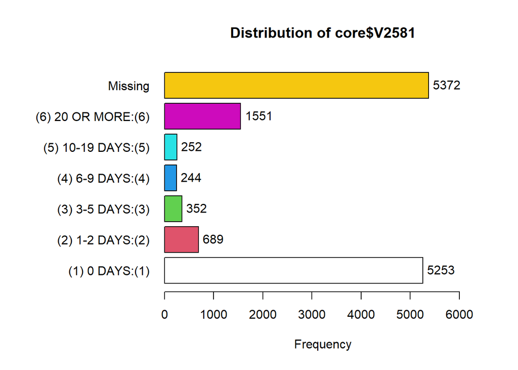

```
## core$V2581 :
##                    Frequency   %(NA+) cum.%(NA+)   %(NA-) cum.%(NA-)
## (1) 0 DAYS:(1)          5253     38.3       38.3     63.0       63.0
## (2) 1-2 DAYS:(2)         689      5.0       43.3      8.3       71.2
## (3) 3-5 DAYS:(3)         352      2.6       45.9      4.2       75.5
## (4) 6-9 DAYS:(4)         244      1.8       47.7      2.9       78.4
## (5) 10-19 DAYS:(5)       252      1.8       49.5      3.0       81.4
## (6) 20 OR MORE:(6)      1551     11.3       60.8     18.6      100.0
## NA's                    5372     39.2      100.0      0.0      100.0
##   Total                13713    100.0      100.0    100.0      100.0
```

```r
tab1(core$V2581, cum.percent = TRUE)
```

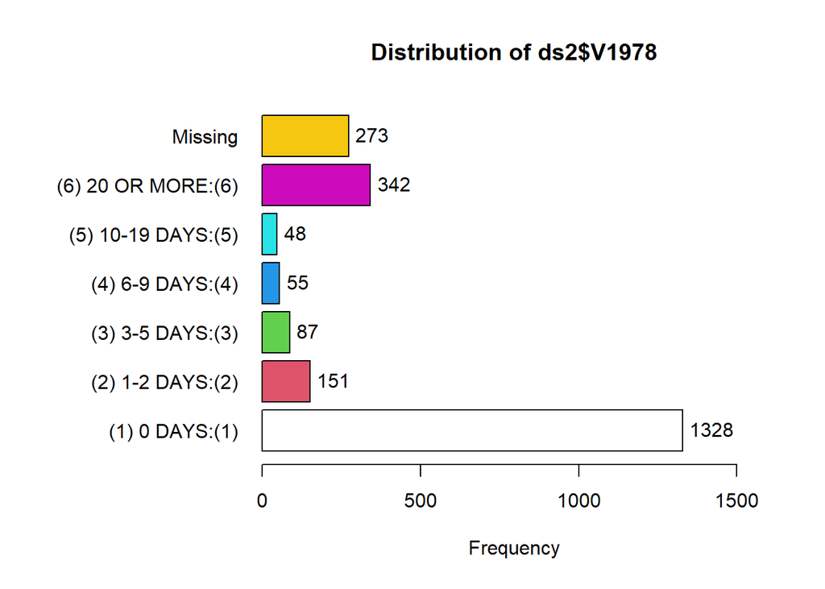

```
## ds2$V1978 :
##                    Frequency   %(NA+) cum.%(NA+)   %(NA-) cum.%(NA-)
## (1) 0 DAYS:(1)          1328     58.1       58.1     66.0       66.0
## (2) 1-2 DAYS:(2)         151      6.6       64.8      7.5       73.5
## (3) 3-5 DAYS:(3)          87      3.8       68.6      4.3       77.9
## (4) 6-9 DAYS:(4)          55      2.4       71.0      2.7       80.6
## (5) 10-19 DAYS:(5)        48      2.1       73.1      2.4       83.0
## (6) 20 OR MORE:(6)       342     15.0       88.0     17.0      100.0
## NA's                     273     12.0      100.0      0.0      100.0
##   Total                 2284    100.0      100.0    100.0      100.0
```

```r
tab1(ds2$V1978, cum.percent = TRUE)
```

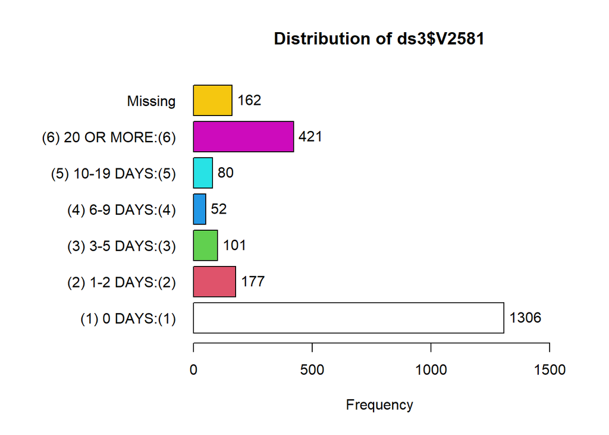

```
## ds3$V2581 :
##                    Frequency   %(NA+) cum.%(NA+)   %(NA-) cum.%(NA-)
## (1) 0 DAYS:(1)          1306     56.8       56.8     61.1       61.1
## (2) 1-2 DAYS:(2)         177      7.7       64.5      8.3       69.4
## (3) 3-5 DAYS:(3)         101      4.4       68.9      4.7       74.1
## (4) 6-9 DAYS:(4)          52      2.3       71.2      2.4       76.6
## (5) 10-19 DAYS:(5)        80      3.5       74.6      3.7       80.3
## (6) 20 OR MORE:(6)       421     18.3       93.0     19.7      100.0
## NA's                     162      7.0      100.0      0.0      100.0
##   Total                 2299    100.0      100.0    100.0      100.0
```

```r
tab1(ds3$V2581, cum.percent = TRUE)
```

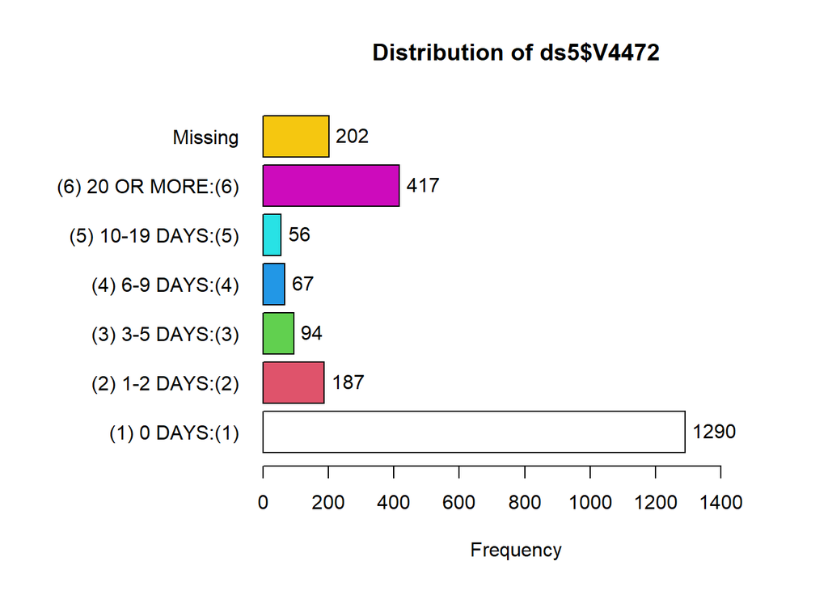

```
## ds5$V4472 :
##                    Frequency   %(NA+) cum.%(NA+)   %(NA-) cum.%(NA-)
## (1) 0 DAYS:(1)          1290     55.8       55.8     61.1       61.1
## (2) 1-2 DAYS:(2)         187      8.1       63.9      8.9       70.0
## (3) 3-5 DAYS:(3)          94      4.1       67.9      4.5       74.4
## (4) 6-9 DAYS:(4)          67      2.9       70.8      3.2       77.6
## (5) 10-19 DAYS:(5)        56      2.4       73.2      2.7       80.2
## (6) 20 OR MORE:(6)       417     18.0       91.3     19.8      100.0
## NA's                     202      8.7      100.0      0.0      100.0
##   Total                 2313    100.0      100.0    100.0      100.0
```

```r
tab1(ds5$V4472, cum.percent = TRUE)
```

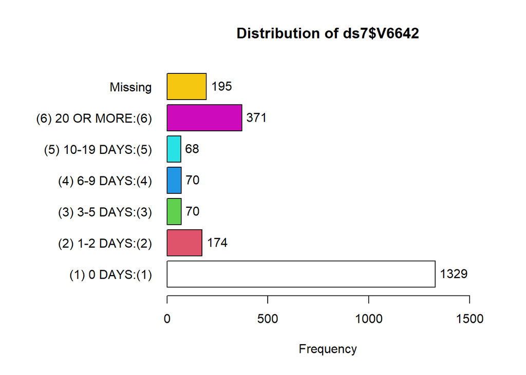

```
## ds7$V6642 :
##                    Frequency   %(NA+) cum.%(NA+)   %(NA-) cum.%(NA-)
## (1) 0 DAYS:(1)          1329     58.4       58.4     63.8       63.8
## (2) 1-2 DAYS:(2)         174      7.6       66.0      8.4       72.2
## (3) 3-5 DAYS:(3)          70      3.1       69.1      3.4       75.6
## (4) 6-9 DAYS:(4)          70      3.1       72.2      3.4       78.9
## (5) 10-19 DAYS:(5)        68      3.0       75.1      3.3       82.2
## (6) 20 OR MORE:(6)       371     16.3       91.4     17.8      100.0
## NA's                     195      8.6      100.0      0.0      100.0
##   Total                 2277    100.0      100.0    100.0      100.0
```

```r
tab1(ds7$V6642, cum.percent = TRUE)
```

### V2584: 35180:#DAYS VAPE MJ/12MO

On how many DAYS (if any) have you vaped MARIJUANA . . . during the last 12 months?

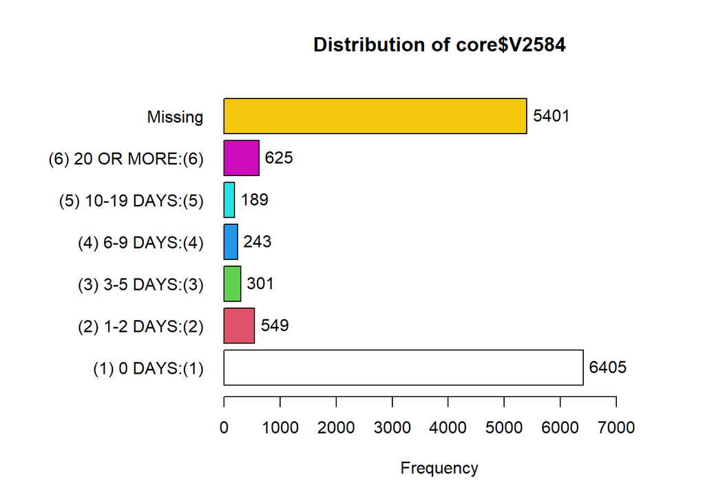

```
## core$V2584 :
##                    Frequency   %(NA+) cum.%(NA+)   %(NA-) cum.%(NA-)
## (1) 0 DAYS:(1)          6405     46.7       46.7     77.1       77.1
## (2) 1-2 DAYS:(2)         549      4.0       50.7      6.6       83.7
## (3) 3-5 DAYS:(3)         301      2.2       52.9      3.6       87.3
## (4) 6-9 DAYS:(4)         243      1.8       54.7      2.9       90.2
## (5) 10-19 DAYS:(5)       189      1.4       56.1      2.3       92.5
## (6) 20 OR MORE:(6)       625      4.6       60.6      7.5      100.0
## NA's                    5401     39.4      100.0      0.0      100.0
##   Total                13713    100.0      100.0    100.0      100.0
```

```r
tab1(core$V2584, cum.percent = TRUE)
```

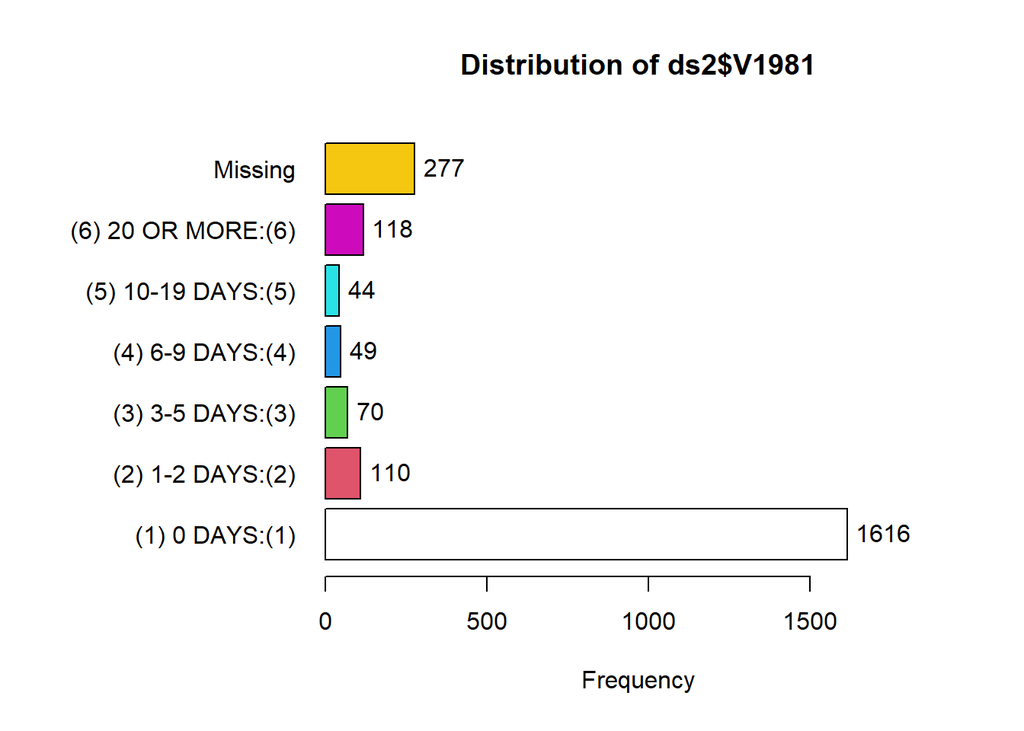

```
## ds2$V1981 :
##                    Frequency   %(NA+) cum.%(NA+)   %(NA-) cum.%(NA-)
## (1) 0 DAYS:(1)          1616     70.8       70.8     80.5       80.5
## (2) 1-2 DAYS:(2)         110      4.8       75.6      5.5       86.0
## (3) 3-5 DAYS:(3)          70      3.1       78.6      3.5       89.5
## (4) 6-9 DAYS:(4)          49      2.1       80.8      2.4       91.9
## (5) 10-19 DAYS:(5)        44      1.9       82.7      2.2       94.1
## (6) 20 OR MORE:(6)       118      5.2       87.9      5.9      100.0
## NA's                     277     12.1      100.0      0.0      100.0
##   Total                 2284    100.0      100.0    100.0      100.0
```

```r
tab1(ds2$V1981, cum.percent = TRUE)
```

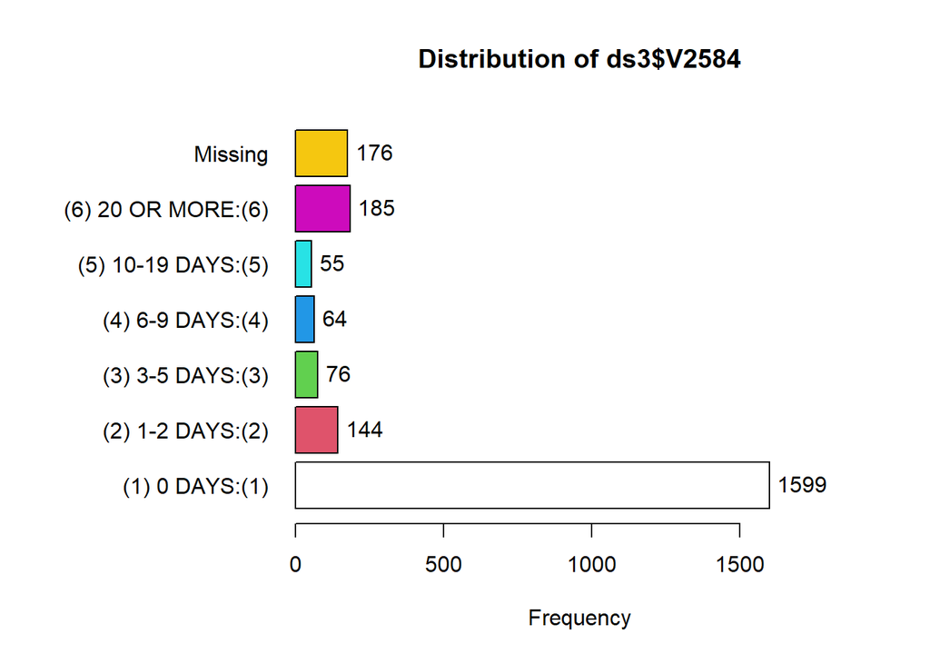

```
## ds3$V2584 :
##                    Frequency   %(NA+) cum.%(NA+)   %(NA-) cum.%(NA-)
## (1) 0 DAYS:(1)          1599     69.6       69.6     75.3       75.3
## (2) 1-2 DAYS:(2)         144      6.3       75.8      6.8       82.1
## (3) 3-5 DAYS:(3)          76      3.3       79.1      3.6       85.7
## (4) 6-9 DAYS:(4)          64      2.8       81.9      3.0       88.7
## (5) 10-19 DAYS:(5)        55      2.4       84.3      2.6       91.3
## (6) 20 OR MORE:(6)       185      8.0       92.3      8.7      100.0
## NA's                     176      7.7      100.0      0.0      100.0
##   Total                 2299    100.0      100.0    100.0      100.0
```

```r
tab1(ds3$V2584, cum.percent = TRUE)
```

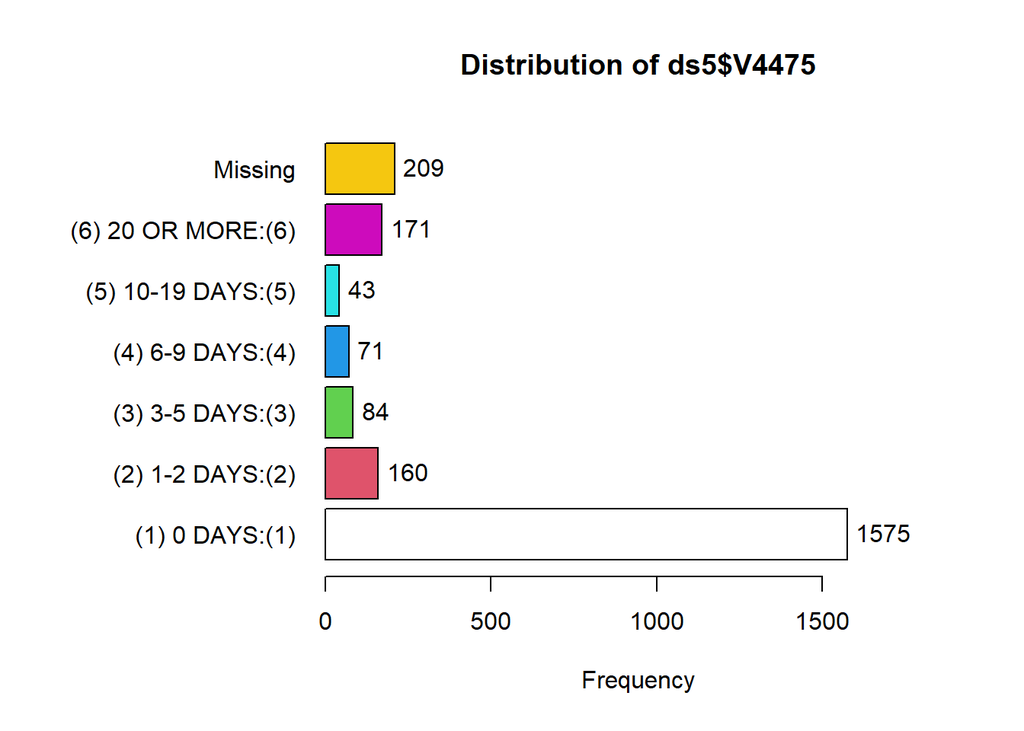

```
## ds5$V4475 :
##                    Frequency   %(NA+) cum.%(NA+)   %(NA-) cum.%(NA-)
## (1) 0 DAYS:(1)          1575     68.1       68.1     74.9       74.9
## (2) 1-2 DAYS:(2)         160      6.9       75.0      7.6       82.5
## (3) 3-5 DAYS:(3)          84      3.6       78.6      4.0       86.5
## (4) 6-9 DAYS:(4)          71      3.1       81.7      3.4       89.8
## (5) 10-19 DAYS:(5)        43      1.9       83.6      2.0       91.9
## (6) 20 OR MORE:(6)       171      7.4       91.0      8.1      100.0
## NA's                     209      9.0      100.0      0.0      100.0
##   Total                 2313    100.0      100.0    100.0      100.0
```

```r
tab1(ds5$V4475, cum.percent = TRUE)
```

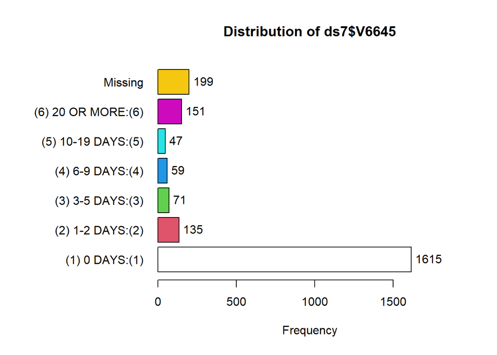

```
## ds7$V6645 :
##                    Frequency   %(NA+) cum.%(NA+)   %(NA-) cum.%(NA-)
## (1) 0 DAYS:(1)          1615     70.9       70.9     77.7       77.7
## (2) 1-2 DAYS:(2)         135      5.9       76.9      6.5       84.2
## (3) 3-5 DAYS:(3)          71      3.1       80.0      3.4       87.6
## (4) 6-9 DAYS:(4)          59      2.6       82.6      2.8       90.5
## (5) 10-19 DAYS:(5)        47      2.1       84.6      2.3       92.7
## (6) 20 OR MORE:(6)       151      6.6       91.3      7.3      100.0
## NA's                     199      8.7      100.0      0.0      100.0
##   Total                 2277    100.0      100.0    100.0      100.0
```

```r
tab1(ds7$V6645, cum.percent = TRUE)
```

# Composite Variable Report

### C0000: Property-related Delinquency

Because all original variables were coded as categorical, and they are all heavily right-skewed, I create the new composite property related delinquency variable by first collapsing each original variables into dichotomous variables, o indicates no experience, 1 indicates have at least some experience. Then, I aggregate all these dichotomous variables to create the new composite variables COOOO.

In this composite variable, 0 means have no property-related delinquency at all, 1 means having committed 1 type of property-related delinquency, 2 means having committed 2 types of property-related delinquency, and it goes on. All NAs are retained.

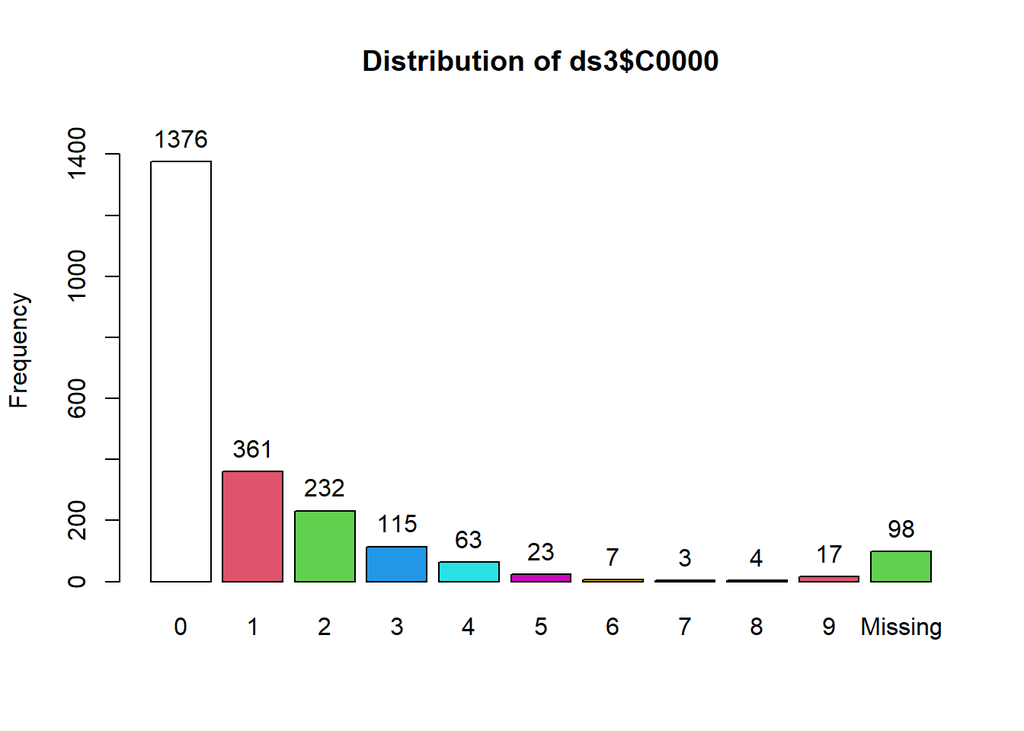

```
## ds3$C0000 :
##         Frequency   %(NA+) cum.%(NA+)   %(NA-) cum.%(NA-)
## 0            1376     59.9       59.9     62.5       62.5
## 1             361     15.7       75.6     16.4       78.9
## 2             232     10.1       85.6     10.5       89.5
## 3             115      5.0       90.6      5.2       94.7
## 4              63      2.7       93.4      2.9       97.5
## 5              23      1.0       94.4      1.0       98.6
## 6               7      0.3       94.7      0.3       98.9
## 7               3      0.1       94.8      0.1       99.0
## 8               4      0.2       95.0      0.2       99.2
## 9              17      0.7       95.7      0.8      100.0
## <NA>           98      4.3      100.0      0.0      100.0
##   Total      2299    100.0      100.0    100.0      100.0
```

```r
library(dplyr)
# Create Numerical Dichotomous Variables
ds3$V2285D<-ifelse(ds3$V2285=="(1) NOT @ALL:(1)",0,1)
ds3$V2286D<-ifelse(ds3$V2286=="(1) NOT @ALL:(1)",0,1)
ds3$V2287D<-ifelse(ds3$V2287=="(1) NOT @ALL:(1)",0,1)
ds3$V2288D<-ifelse(ds3$V2288=="(1) NOT @ALL:(1)",0,1)
ds3$V2289D<-ifelse(ds3$V2289=="(1) NOT @ALL:(1)",0,1)
ds3$V2290D<-ifelse(ds3$V2290=="(1) NOT @ALL:(1)",0,1)
ds3$V2291D<-ifelse(ds3$V2291=="(1) NOT @ALL:(1)",0,1)
ds3$V2292D<-ifelse(ds3$V2292=="(1) NOT @ALL:(1)",0,1)
ds3$V2293D<-ifelse(ds3$V2293=="(1) NOT @ALL:(1)",0,1)

# Sum these dichotomous
ds3$C0000 <- ds3$V2285D + ds3$V2286D + ds3$V2287D + ds3$V2288D + ds3$V2289D + ds3$V2290D + ds3$V2291D + ds3$V2292D + ds3$V2293D

# Showing the distribution of the new composite variable
tab1(ds3$C0000, cum.percent = TRUE)
```

### C0001: Violent Delinquency

The making of the composite violdent delinquency variable follows the same logic described above in the property-related delinquency.

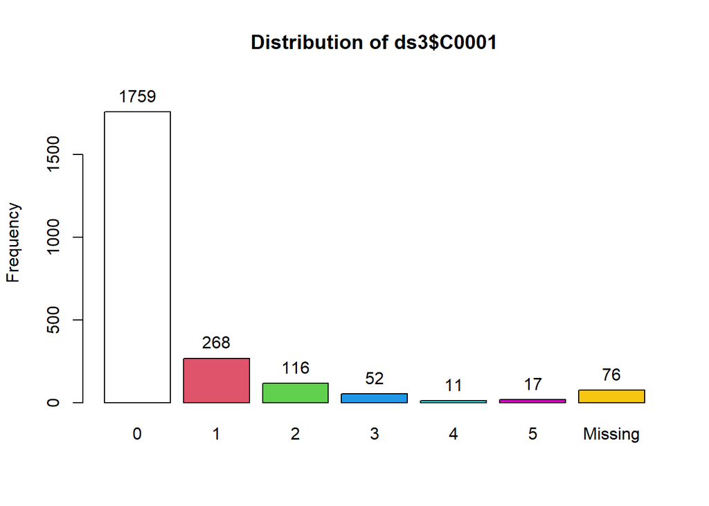

```
## ds3$C0001 :
##         Frequency   %(NA+) cum.%(NA+)   %(NA-) cum.%(NA-)
## 0            1759     76.5       76.5     79.1       79.1
## 1             268     11.7       88.2     12.1       91.2
## 2             116      5.0       93.2      5.2       96.4
## 3              52      2.3       95.5      2.3       98.7
## 4              11      0.5       96.0      0.5       99.2
## 5              17      0.7       96.7      0.8      100.0
## <NA>           76      3.3      100.0      0.0      100.0
##   Total      2299    100.0      100.0    100.0      100.0
```

```r
# Creating numerical dichotomous variables
ds3$V2280D<-ifelse(ds3$V2280=="(1) NOT @ALL:(1)",0,1)
ds3$V2281D<-ifelse(ds3$V2281=="(1) NOT @ALL:(1)",0,1)
ds3$V2282D<-ifelse(ds3$V2282=="(1) NOT @ALL:(1)",0,1)
ds3$V2283D<-ifelse(ds3$V2283=="(1) NOT @ALL:(1)",0,1)
ds3$V2284D<-ifelse(ds3$V2284=="(1) NOT @ALL:(1)",0,1)

# Sum accross these variables:
ds3$C0001 <- ds3$V2280D + ds3$V2281D + ds3$V2282D + ds3$V2283D + ds3$V2284D

# Showing the distribution:
tab1(ds3$C0001, cum.percent = TRUE)
```